# Análisis Estadístico de la Personalidad

## Resumen

El presente informe reúne elementos elementos estadísticos en un contexto psicológico. Estaremos interesados en abordar la personalidad desde una perspectiva científica, en particular, reduccionista. A traves del analisis de respuestas a una encuesta de personalidad queremos ver qué podemos aprender de ella y de las relaciones entre sus respuestas y la personalidad de las y los individuos. Basaremos este análisis desde un enfoque de análisis factorial, es decir, un análisis de estructuras, estas estructuras se explican principalmente en términos de variabilidad. Finalmente veremos si estos factores presentan cambios según condicionalizamos nuestro grupo de estudio en alguna característica de la población como puede ser edad, raza o género. es decir testeamos alguna hipótesis respecto a que la personalidad depende de alguno de estas características de la población.

## Introducción

Es sabido para cualquiera que reflexione acerca de la personalidad propia o del resto de individuos que le rodean, que este es un fenómeno complejo y hasta parece indescriptible. Sin embargo, solemos categorizar a las personas según nuestras propias experiencias desde categorías básicas como entre aquellos y aquellas que son de nuestro agrado o no, y clasificaciones más complejas como otorgarles adjetivos de inteligencia, sociabilidad, violencia entre múltiples otros.

La idea de este trabajo es estudiar una metodología que explora la posibilidad de dar una medición o evaluación de la personalidad de un individuo, sin embargo dado la aparente complejidad de este fenómeno nos interesamos en estudiarla desde una manera reductiva y preguntarnos si podemos clasificar los múltiples rasgos que atribuimos a las personas en dimensiones reducidas ¿existirán estas dimensiones? ¿cómo las evaluamos? estas son algunas preguntas que intentaremos abordar en la presente monografía y que son importantes desde un punto de vista intelectual pero también práctico ya que permiten pensar en nuevos horizontes para la exploración de la salud mental de las poblaciones y naciones ya que dotan a los médicos con nuevas herramientas para evaluar lo no observable de la mente humana. (véase Galton, F. Inquiries into Human Faculty and its Development y https://www.psychologytools.com/download-scales-and-measures/)

Para atacar estas preguntas de investigación utilizaremos los datos del Big Five Personality Test publicados por la Open-Source Psychometrics Project.

## Antecedentes

Existe una teoría denominada la teoría de los grandes cinco rasgos que establece respuestas afirmativas a las preguntas anteriormente planteadas, está teoría está apoyada empíricamente en investigaciones sobre las descripciones de personalidad que unas personas hacían de otras(véase Digman JM (1990). “Personality structure: Emergence of the five-factor model”. Annual Review of Psychology.). A través de múltiples esfuerzos desde la década del 30 hasta que fue organizada en su nivel más alto por lewis goldberg en su artículo “The structure of phenotypic personality traits”

## Los datos

Los datos que usaremos para la exploración de está teoría pertenecen a un test aplicado de manera online por el Open-Source Psychometrics Project y la información recolectada fue raza, edad, género, ingles nativo (si son hablantes de inglés nativo) así se recolecta las respuestas de los individuos participantes (19719 para este estudio) a las siguiente 50 preguntas en una escala de 5 puntos correspondientes a:

1=Disagree, 3=Neutral, 5=Agree (0=missed).

Las preguntas son las siguientes (en inglés)

- E1 I am the life of the party.
- E2 I don’t talk a lot.
- E3 I feel comfortable around people.
- E4 I keep in the background.
- E5 I start conversations.
- E6 I have little to say.
- E7 I talk to a lot of different people at parties.
- E8 I don’t like to draw attention to myself.
- E9 I don’t mind being the center of attention.
- E10 I am quiet around strangers.
- N1 I get stressed out easily.
- N2 I am relaxed most of the time.
- N3 I worry about things.
- N4 I seldom feel blue.
- N5 I am easily disturbed.
- N6 I get upset easily.
- N7 I change my mood a lot.
- N8 I have frequent mood swings.
- N9 I get irritated easily.
- N10 I often feel blue.
- A1 I feel little concern for others.
- A2 I am interested in people.
- A3 I insult people.
- A4 I sympathize with others’ feelings.
- A5 I am not interested in other people’s problems.
- A6 I have a soft heart.
- A7 I am not really interested in others.
- A8 I take time out for others.
- A9 I feel others’ emotions.
- A10 I make people feel at ease.
- C1 I am always prepared.
- C2 I leave my belongings around.
- C3 I pay attention to details.
- C4 I make a mess of things.
- C5 I get chores done right away.
- C6 I often forget to put things back in their proper place.
- C7 I like order.
- C8 I shirk my duties.
- C9 I follow a schedule.
- C10 I am exacting in my work.
- O1 I have a rich vocabulary.
- O2 I have difficulty understanding abstract ideas.
- O3 I have a vivid imagination.
- O4 I am not interested in abstract ideas.
- O5 I have excellent ideas.
- O6 I do not have a good imagination.
- O7 I am quick to understand things.
- O8 I use difficult words.
- O9 I spend time reflecting on things.
- O10 I am full of ideas.

## Resultados

A continuación presentamos los resultados en el orden que se realizó el análisis todo desde un enfoque de analisi factorial en búsqueda de estructuras las cuales se definen en término de variabilidad que denominamos factores y hacen analogía a los determinantes de la personalidad que agrupan como una gran dimensión las sutilezas y múltiples facetas de las personalidades de las y los individuos, comenzamos con un análisis exploratorio para guiar asi nuestras hipótesis de la existencia de factores, una vez que estas hipótesis consigan sustento empírico procederemos a realizar el análisis factorial propiamente tal y comentaremos los resultados.

## Análisis exploratorio

Un primer intento de buscar dimensiones de la personalidad basada en las respuestas de los participantes de la encuesta es mirar un mapa de calor y así visualizar si hay preguntas que se agrupen entre ellas, lo que nos dará una primera pista de factores latentes que puedan revelar una estructura de la personalidad. Así procedemos a crear un mapa de calor con los datos de la encuesta, obteniendo la siguiente figura:

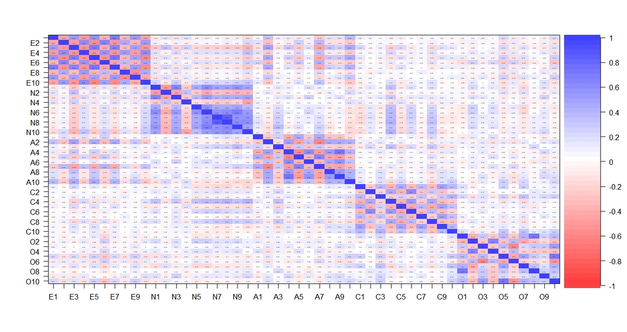

De aquí podemos ver que las respuestas se agrupan en 5 grandes grupos ¿serán estos grupos los factores de la personalidad que estamos buscando?

## Analisis Factorial de los rasgos de la personalidad

Una vez que tenemos indicios de que existen factores que explican la personalidad podemos ver un análisis factorial y ver si modelar las respuestas de la encuesta con estos cincos factores observados en el mapa de calor hacen sentido o no.

Para ello primero veremos un gráfico denominado scree plot el cual nos puede aportar evidencia a favor de los 5 factores observados en el mapa de calor o evidencia en contra. Lo que este gráfico nos muestra de manera coloquial es cuánta varianza de los datos se explica por cada factor que agregamos para explicar los datos.

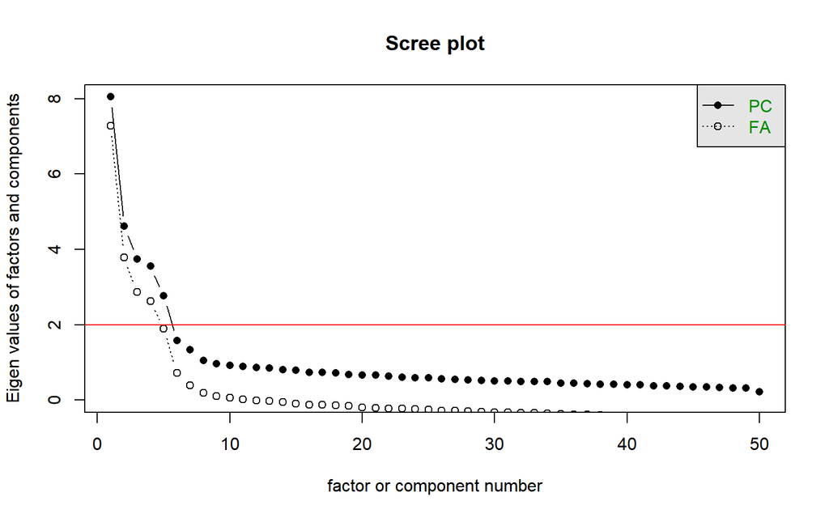

De este grafico podemos concluir que luego del quinto factor la varianza explicada comienza a ser marginal, por lo que nuestra conjetura de que hay 5 dimensiones preponderantes en la personalidad va tomando más fuerza. Esto a su vez se visualiza como un “todo” determinado por la línea roja del gráfico 1.

Ahora ya estamos en pie firme para realizar un análisis factorial que es ver algunas métricas relacionadas a los factores hipotéticos y ver si hacen sentido con lo esperado, por ejemplo si estos factores son suficientes para explicar las respuestas esperaremos una baja correlación entre ellos pues estamos diciendo que los factores explican aptitudes o características diferentes de la personalidad de cada individuo por lo que esperamos que lo que explica un factor sea poco explicado por otro factor.

|  | ULS1 | ULS2 | ULS5 | ULS4 | ULS3 |
| --- | --- | --- | --- | --- | --- |
| SS loadings | 5.70 | 5.14 | 4.35 | 3.88 | 3.71 |
| Proportion Var | 0.11 | 0.10 | 0.09 | 0.08 | 0.07 |
| Cumulative Var | 0.11 | 0.22 | 0.30 | 0.38 | 0.46 |
| Proportion Explained | 0.25 | 0.23 | 0.19 | 0.17 | 0.16 |
| Cumulative Proportion | 0.25 | 0.48 | 0.67 | 0.84 | 1.00 |

Lo primero que observamos de la salida del análisis factorial es que los 5 factores explican de manera aproximadamente equilibrada la variabilidad de los datos lo que causa satisfacción ya que nos habla de una cierta parsimonia presente en los 5 factores.

Lo segundo que podemos observar es la correlación entre los factores en la siguiente tabla

|  | ULS1 | ULS2 | ULS5 | ULS4 | ULS3 |
| --- | --- | --- | --- | --- | --- |
| ULS1 | 1.00 | -0.24 | 0.25 | 0.16 | 0.08 |
| ULS2 | -0.24 | 1.00 | -0.03 | -0.07 | -0.23 |
| ULS5 | 0.25 | -0.03 | 1.00 | 0.10 | 0.15 |
| ULS4 | 0.16 | -0.07 | 0.10 | 1.00 | 0.05 |
| ULS3 | 0.08 | -0.23 | 0.15 | 0.05 | 1.00 |

De lo cual podemos ver que las correlaciones entre factores son bajas o negativas lo que indica que los factores están explicando distintas facetas de los datos lo que es consistente con la hipótesis previa de que de existir estos factores deberían estar poco correlacionados.

## ¿Existe evidencia para decir que la personalidad depende del género del individuo?

Es súper común escuchar atribuciones o caracteristica a la personalidad de los individuos acorde a su sexo registral, por ejmplo: “las mujeres son histericas” o “los hombres son mas violentos que las mujeres” ¿podemos sustentar este tipo de afirmación en los datos de las +19000 personas que respondieron la encuesta de personalidad?

Para responder esto haremos un test de hipótesis de diferencia de medias o t-test y presentaremos los p valores para ver los resultados completos revisar Anexo. La sintaxis que usamos para reportar las hipótesis es la siguiente: Factor j ~ Género quiere decir: ¿son las respuestas agrupadas en el factor j dependientes del género del individuo que responde?

| Hipótesis | p-valor |
| --- | --- |
| Factor 1 ~ Género | < 2.2e-16 |
| Factor 2 ~ Género | = 7.809e-10 |
| Factor 3 ~ Género | < 2.2e-16 |
| Factor 4 ~ Género | = 1.918e-12 |
| Factor 5 ~ Género | < 2.2e-16 |

Observamos p valores muy pequeños para cada uno de los factores, es decir que la probabilidad de observar estas diferencias de respuesta para cada dimensión de la personalidad bajo el supuesto de la hipótesis nula(que no hay diferencia según género) es muy improbable, por tanto rechazamos la hipótesis de que la respuesta al cuestionario no depende del género y que al menos estos datos sí sugieren que el género afecta en la personalidad de las personas, lo que no es justificación para hacer afirmaciones discriminatorias, si no que fuente de investigación futura tanto psicológica como biológica para comprender mejor la naturaleza humana, sus necesidades y desafíos.

## Conclusiones

Luego de los análisis podemos observar que emergen estructuras dentro de los datos, las respuestas se agrupan en dimensiones que denominamos factores. De hecho estas preguntas vienen codificadas con una letra y un número, efectivamente la letra hace referencia a la dimensión que corresponde el adjetivo que se utiliza en la pregunta. Esto proviene de la hipótesis léxica que se atribuye a Francis Galton y se considera el inicio del estudio científico de la personalidad. Estos factores se obtuvieron luego de mucha investigación la cual se culmina en el trabajo de Goldberg “The structure of phenotypic personality traits” y las categorías o dimensiones de la personalidad hacen referencia a:

- Apertura a la experiencia
- Escrupulosidad
- Extroversión
- Amabilidad
- Neuroticismo

Es sorprendente como algo en apariencia tan complejo como la personalidad pueda ser visto desde un pequeño puñado de elementos que permiten describir un fenómeno de amplio espectro.

Como trabajo futuro se abren muchas puertas, por ejemplo de mi particular interés: como utilizar esto para diagnósticos más certeros en cuanto a la salud mental de las personas.

## Referencias

- Digman JM (1990). “Personality structure: Emergence of the five-factor model”. Annual Review of Psychology.
- Galton, F. (1883). Inquiries into human faculty and its development. London: Macmillan
- Goldberg LR (January 1993). “The structure of phenotypic personality traits”. The American Psychologist.

## Bibliografía

- Cattell HE (1996). “The original big five: A historical perspective”. European Review of Applied Psychology.
- Costa PT, Terracciano A, McCrae RR (August 2001). “Gender differences in personality traits across cultures: robust and surprising findings”. Journal of Personality and Social Psychology.
- Galton, F. (1949). The Measurement of Character
- Schmitt DP, Realo A, Voracek M, Allik J (January 2008). “Why can’t a man be more like a woman? Sex differences in Big Five personality traits across 55 cultures”. Journal of Personality and Social Psychology.

## Anexo

```
##
##  Welch Two Sample t-test
##
## data:  base[base$gender == 1, Factor_O] and base[base$gender == 2, Factor_O]
## t = 8.6604, df = 157695, p-value < 2.2e-16
## alternative hypothesis: true difference in means is not equal to 0
## 95 percent confidence interval:
##  0.04336550 0.06873557
## sample estimates:
## mean of x mean of y
##  3.347148  3.291097
```

```
##
##  Welch Two Sample t-test
##
## data:  base[base$gender == 1, Factor_C] and base[base$gender == 2, Factor_C]
## t = -6.1491, df = 162530, p-value = 7.809e-10
## alternative hypothesis: true difference in means is not equal to 0
## 95 percent confidence interval:
##  -0.04827415 -0.02493833
## sample estimates:
## mean of x mean of y
##  3.131979  3.168586
```

```
##
##  Welch Two Sample t-test
##
## data:  base[base$gender == 1, Factor_E] and base[base$gender == 2, Factor_E]
## t = 8.7974, df = 162987, p-value < 2.2e-16
## alternative hypothesis: true difference in means is not equal to 0
## 95 percent confidence interval:
##  0.04252019 0.06689750
## sample estimates:
## mean of x mean of y
##  3.110620  3.055912
```

```
##
##  Welch Two Sample t-test
##
## data:  base[base$gender == 1, Factor_A] and base[base$gender == 2, Factor_A]
## t = -7.0408, df = 171220, p-value = 1.918e-12
## alternative hypothesis: true difference in means is not equal to 0
## 95 percent confidence interval:
##  -0.05747225 -0.03244235
## sample estimates:
## mean of x mean of y
##  3.177813  3.222770
```

```
##
##  Welch Two Sample t-test
##
## data:  base[base$gender == 1, Factor_N] and base[base$gender == 2, Factor_N]
## t = -32.46, df = 159463, p-value < 2.2e-16
## alternative hypothesis: true difference in means is not equal to 0
## 95 percent confidence interval:
##  -0.2089465 -0.1851502
## sample estimates:
## mean of x mean of y
##  2.974040  3.171089
```